# Homework #2: Resampling

Nicholas Keeley

Due: Tue Sept 14 | 3:25pm

**DS 6030 | Fall 2021 | University of Virginia**

NOTE: Patrick Corbett helped talk me through the theory, and subsequently the code for the CI problem. Despite following the same code, I was not able to produce the desired result. I’ve left the code as is to reflect my attempt, and am hoping to receive partial credit for attempting. I also had serious problems with DPLYR for some reason, so this may have been part of the issue.

# Required R packages and Directories

```r
data.dir = 'https://mdporter.github.io/DS6030/data/' # data directory
library("R6030")     # functions for DS-6030
library("tidyverse") # functions for data manipulation
library("dplyr")
library("ISLR")
library("moderndive")
library("rpart")
library("rpart.plot")
library("randomForest")
library("boot")
library("caret")
library("broom")
library("glmnet")
library("FNN")
library("modelr")
library("tidymodels")
library("e1071")
library("MASS")
library("fitdistrplus")
library("ks")
library("mclust")
library("mixtools")
library("gbm")
library("xgboost")
library("arules")
library("igraph")
```

# Problem 1: Bootstrapping

Bootstrap resampling can be used to quantify the uncertainty in a fitted curve.

## a. Create a set of functions to generate data from the following distributions:

$$\begin{align*}
X &\sim \mathcal{U}(0, 2) \qquad \text{Uniform in $[0,2]$}\\
Y &= 1 + 2x + 5\sin(5x) + \epsilon \\
\epsilon &\sim \mathcal{N}(0,\, \sigma=2.5)
\end{align*}$$

## b. Simulate $n=100$ realizations from these distributions. Produce a scatterplot and draw the true regression line $f(x) = E[Y \mid X=x]$. Use `set.seed(211)` prior to generating the data.

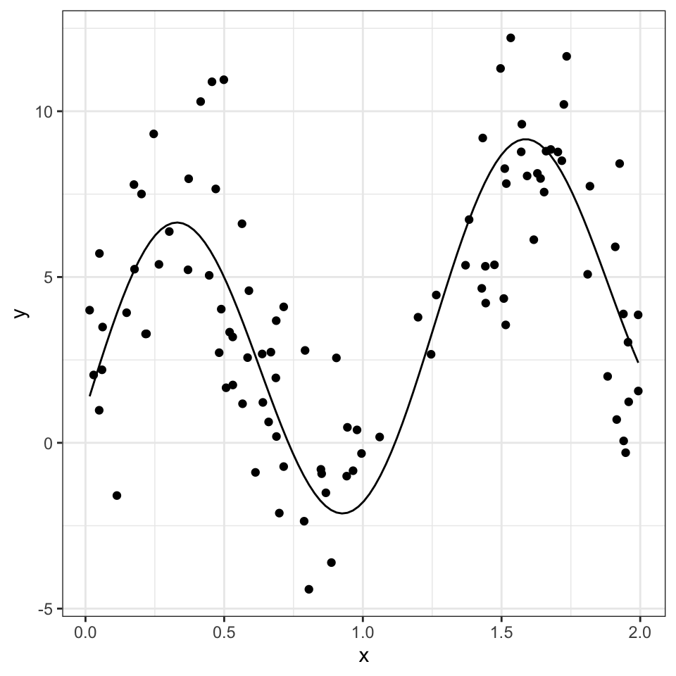

```r
## Scatterplot with true population in black.

ggplot(aes(x, y), data=tibble(x,y)) +
geom_point() +
geom_function(fun=sim_true,color="black")
```

## c. Fit a 5th degree polynomial. Produce a scatterplot and draw the *estimated* regression curve.

```r
## Sequence of x's to predict along

xseq=seq(0,2,length=100)
models$xseq=xseq

## Fifth degree polynomial

m1=lm(y~poly(x,5))
y_hat1=predict(m1,newdata=tibble(xseq))
models$fifth=y_hat1
```

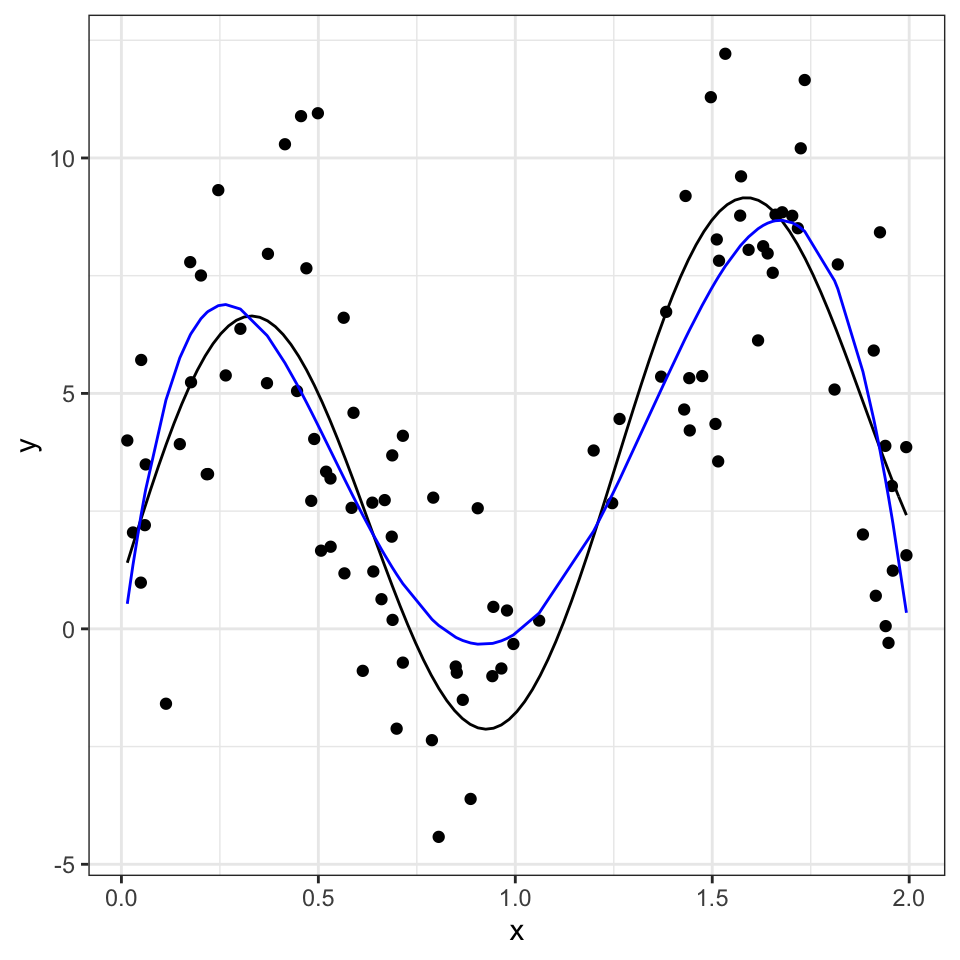

```r
## Scatterplot with true population in black and estimated model in blue

ggplot(aes(x, y), data=models) +
geom_point() +
geom_function(fun=sim_true,color="black") +
geom_line(aes(y=models$fifth),color = "blue")
```

## d. Draw 200 bootstrap samples, fit a 5th degree polynomial to each bootstrap sample, and make predictions at `eval.pts = seq(0, 2, length=100)`

- Set the seed (use `set.seed(212)`) so your results are reproducible.
- Produce a scatterplot and add the 200 bootstrap curves

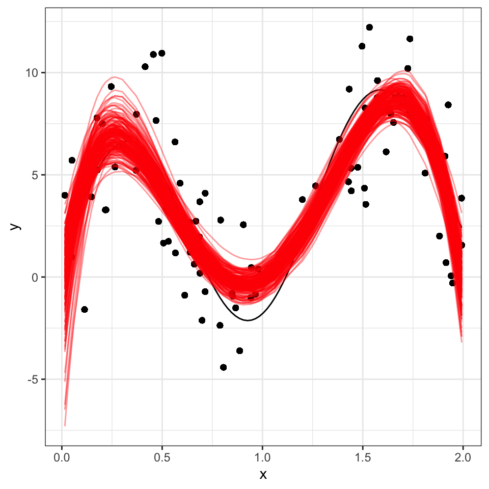

```r
## Scatterplot with true population in black and estimated model in blue

ggplot(aes(x, y), data=df_long) +
geom_point() +
geom_function(fun=sim_true,color="black") +
geom_line(data=df_long, color="red", alpha=0.4, aes(y=prediction,group=model))
```

## e. Calculate the pointwise 95% confidence intervals from the bootstrap samples. That is, for each $x \in {\rm eval.pts}$, calculate the upper and lower limits such that only 5% of the curves fall outside the interval at $x$.

- Remake the plot from part *c*, but add the upper and lower boundaries from the 95% confidence intervals.

NOTE TO GRADER: I could not get this code to run, but consulted with other students who had very similar code. The idea is correct, but something didn’t go right with the mapping. Credit for help: Patrick Corbett

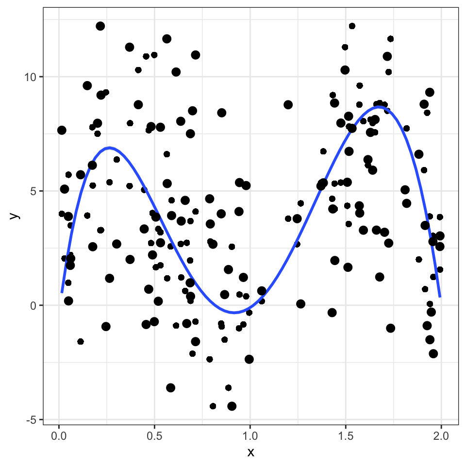

```r
ggplot(aes(x, y), data=df_long) +
  geom_point() +
  geom_smooth(method="lm", formula = "y~poly(x,5)") +
  geom_pointrange(df_long %>% group_by(x) %>% summarize(sd=sd(y), mean=mean(y)), mapping = aes(ymin= mean- 2*sd, ymax = mean + 2*sd))
```

# Problem 2: V-Fold cross-validation with $k$ nearest neighbors

Run 10-fold cross-validation on the data generated in part 1b to select the optimal $k$ in a k-nearest neighbor (kNN) model. Then evaluate how well cross-validation performed by evaluating the performance on a large test set. The steps below will guide you.

## a. Use $10$-fold cross-validation to find the value of $k$ (i.e., neighborhood size) that provides the smallest cross-validated MSE using a kNN model.

- Search over $k=3,4,\ldots, 50$.
- Use `set.seed(221)` prior to generating the folds to ensure the results are replicable.
- Show the following:
  - the optimal $k$ (as determined by cross-validation)
  - the corresponding estimated MSE
  - produce a plot with $k$ on the x-axis and the estimated MSE on the y-axis (optional: add 1-standard error bars).
- Notation: *v*-fold cross-validation; *k*-nearest neighbor. Don’t get yourself confused.

```r
## Create KNN model for k=3

#knn.3 = knn.reg(df2$x, test=tibble(eval.pts), y=df2$y,k=3)

#mse=mean((df2$y-knn.3$pred)^2)

model_result=function(data_fit, data_eval, k){
  result = knn.reg(dplyr::select(data_fit,x), test=dplyr::select(data_eval,x), y=data_fit$y, k=k)
}


## Set up folds
df2=tibble(df2)
n=nrow(df2)
n.folds=10
set.seed(221)
folds=sample(rep(1:n.folds,length=n))

## Loop for each k attempted

RESULTS = matrix(NA,10,50)
#- Iterate over folds

## For a given k (# of neighbors), conducting 10 fold validation

#-- Set training/val data
for(k in 3:50){
  for(j in 1:n.folds){
    val = which(folds == j) # indices of holdout/validation data
    train = which(folds != j) # indices of fitting/training data
    n.val = length(val) # number of observations in validation
    #- fit and evaluate models
    results = model_result(
            data_fit = dplyr::slice(df2, train),
            data_eval = dplyr::slice(df2, val),
            k=k)
    temp_preds=results$pred
    temp_valset=dplyr::slice(df2, val)
    results=tibble(prediction = temp_preds,
                   actual = temp_valset$y)
    mse = mean((results$actual-results$prediction)^2) ## MSE for this validation fold
    RESULTS[j,k]=mse # Save into results table
  }
}

## Now find the MSE for each k and format table

RESULTS=RESULTS[,3:50]
names=c(seq(3,50))
colnames(RESULTS)=names
RESULTS_2=matrix(NA,1,48)
colnames(RESULTS_2)=names

for(i in 1:48){
  RESULTS_2[i]=mean(RESULTS[,i])
}

RESULTS_2=rbind(RESULTS_2,names)
RESULTS_2=as_tibble(RESULTS_2)

RESULTS_long=pivot_longer(RESULTS_2,cols=everything(), names_to="k",values_to="mse")
RESULTS_long=RESULTS_long[1:48,]
RESULTS_long$k=as.numeric(RESULTS_long$k)
RESULTS_long %>% arrange(desc(as.numeric(RESULTS_long$k)))
```

| k | mse |
| --- | --- |
| 50 | 13.142 |
| 49 | 12.915 |
| 48 | 12.620 |
| 47 | 12.367 |
| 46 | 12.099 |
| 45 | 11.782 |
| 44 | 11.449 |
| 43 | 11.200 |
| 42 | 10.957 |
| 41 | 10.698 |

[output cut: 38 more lines]

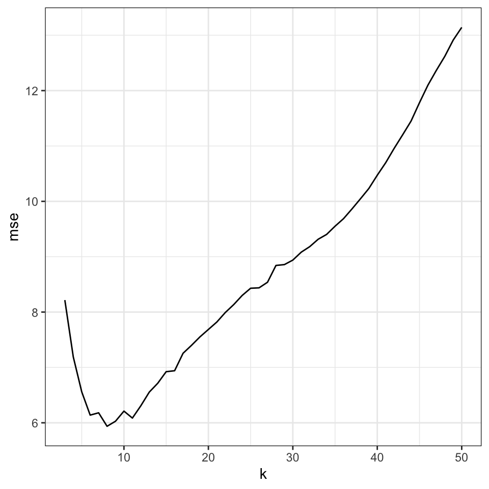

```r
ggplot(aes(k, mse), data=RESULTS_long) +
geom_line()
```

```r
## Display minimum true MSE

temp=group_by(RESULTS_long, k)
temp
```

| k | mse |
| --- | --- |
| 3 | 8.216 |
| 4 | 7.189 |
| 5 | 6.559 |
| 6 | 6.139 |
| 7 | 6.181 |
| 8 | 5.937 |
| 9 | 6.028 |
| 10 | 6.211 |
| 11 | 6.085 |
| 12 | 6.308 |

[output cut: 38 more lines]

## b. The $k$ (number of neighbors) in a kNN model determines the effective degrees of freedom *edf*. What is the optimal *edf*? Be sure to use the correct sample size when making this calculation. Produce a plot similar to that from part *a*, but use *edf* (effective degrees of freedom) on the x-axis.

```r
## Add effective degrees of freedom

n=100
RESULTS_long$edf=n/RESULTS_long$k
temp=group_by(RESULTS_long, k)
temp
```

| k | mse | edf |
| --- | --- | --- |
| 3 | 8.216 | 33.333 |
| 4 | 7.189 | 25.000 |
| 5 | 6.559 | 20.000 |
| 6 | 6.139 | 16.667 |
| 7 | 6.181 | 14.286 |
| 8 | 5.937 | 12.500 |
| 9 | 6.028 | 11.111 |
| 10 | 6.211 | 10.000 |
| 11 | 6.085 | 9.091 |
| 12 | 6.308 | 8.333 |

[output cut: 38 more lines]

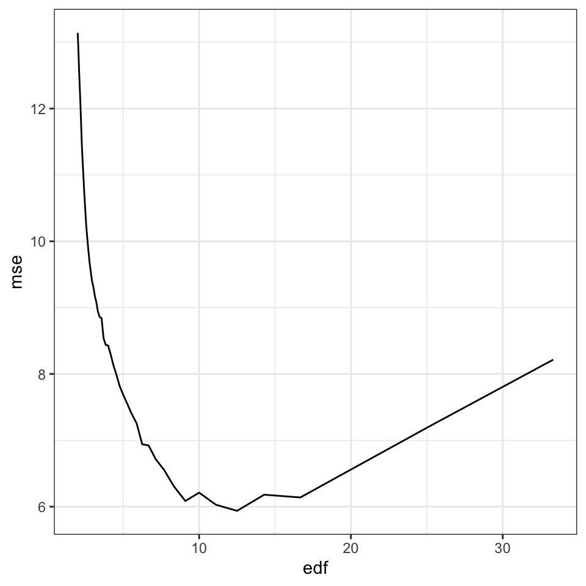

```r
## Plot edf vs. mse

ggplot(aes(edf, mse), data=RESULTS_long) +
geom_line()
```

## c. After running cross-validation, a final model fit from *all* of the training data needs to be produced to make predictions. What value of $k$ would you choose? Why?

I want to choose the value of k for which TEST MSE is minimized, rather than TRAIN MSE. If we simply select the k for which TRAIN MSE is minimized, then we might fall prey to overfitting. TEST MSE is our chief concern when we want to make predictions.

## d. Now we will see how well cross-validation performed. Simulate a test data set of $50000$ observations from the same distributions. Use `set.seed(223)` prior to generating the test data.

- Fit a set of kNN models, using the full training data, and calculate the mean squared error (MSE) on the test data for each model. Use the same $k$ values in *a*.
- Report the optimal $k$, the corresponding *edf*, and MSE based on the test set.

The optimal test MSE is 7.109, for which k is 13 and edf is 3846.

[output not shown]

```r
RESULTS_d
```

| v | mse | k | edf |
| --- | --- | --- | --- |
| V1 | 7.913 | 3 | 16667 |
| V2 | 7.568 | 4 | 12500 |
| V3 | 7.422 | 5 | 10000 |
| V4 | 7.303 | 6 | 8333 |
| V5 | 7.258 | 7 | 7143 |
| V6 | 7.144 | 8 | 6250 |
| V7 | 7.188 | 9 | 5556 |
| V8 | 7.147 | 10 | 5000 |
| V9 | 7.169 | 11 | 4545 |
| V10 | 7.126 | 12 | 4167 |

[output cut: 38 more lines]

## e. Plot both the cross-validation estimated and (true) error calculated from the test data on the same plot. See Figure 5.6 in ISL (pg 182) as a guide.

- Produce two plots: one with $k$ on the x-axis and one with *edf* on the x-axis.
- Each plot should have two lines: one from part *a* and one from part *d*

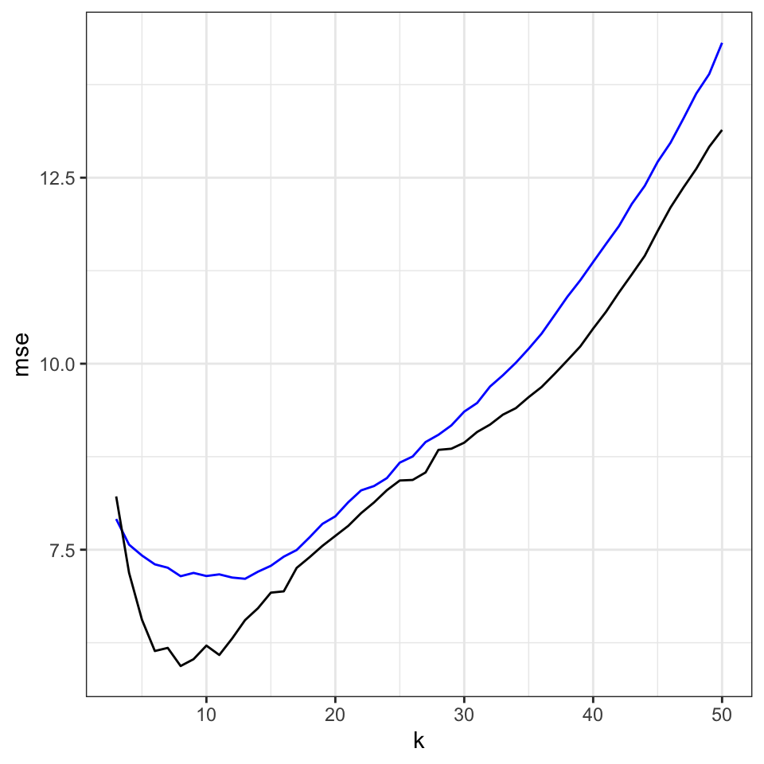

```r
## Plot k vs. mse

ggplot(aes(k, mse), data=RESULTS_d) +
geom_line(data=RESULTS_d, color="blue") +
  geom_line(data=RESULTS_long, color="black")
```

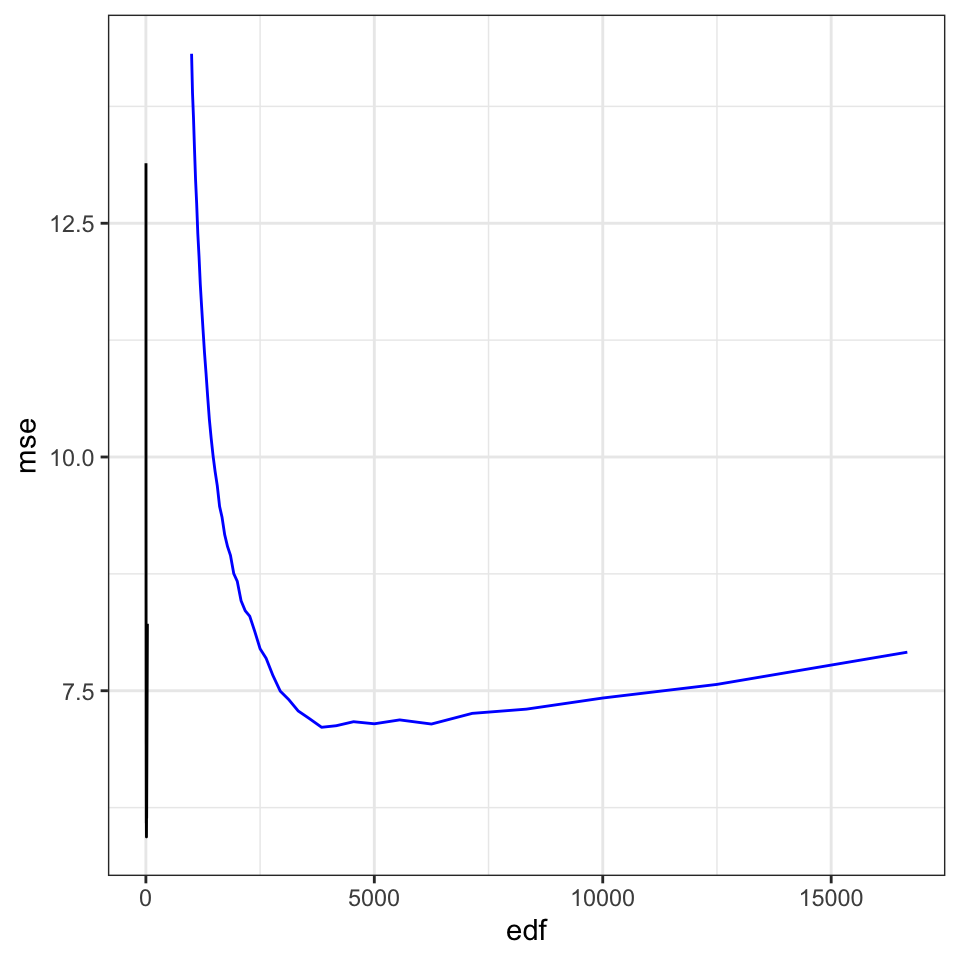

```r
## Plot edf vs. mse

ggplot(aes(edf, mse), data=RESULTS_long) +
  geom_line(data=RESULTS_d, color="blue") +
  geom_line(data=RESULTS_long, color="black")
```